# Ranking Severe Weather Consequences on Population Health and Economy

## Synopsis

Storms and severe weather events can cause both enormous devastations to public health and economy in communities and municipalities. Many severe events can result in fatalities, injuries, and property/crop damage. While it is impractical to prevent severe weather events from forming, a key concern is to plan and prepare for such events to the extent possible to reduce undesirable outcomes. Knowing the most potentially damaging events is a key aspect to prioritize resources during planning and policymaking.

Exploring the U.S. National Oceanic and Atmospheric Administration’s, [NOAA](http://www.nws.noaa.gov/directives/), storm database that tracks the characteristics of major storms and weather events in the United States, it was possible to rank both the health impact and monetary damage value for weather events across the United States. This report obtained and analyzed pertinent data from NOAA and prepared the results by ranking sever weather events impact on public health and property/crop damage. The results show that tornado has by far resulted in most fatality and injuries, while flood has caused the most economic damage.

## Research Question

This report aims to answer the following questions

- Across the United States, which types of events are most harmful with respect to population health?
- Across the United States, which types of events have the greatest economic consequences?

## Key Steps

The following steps were followed to perform the research

- Data Processing
- Data Analysis
- Interpretations
- Conclusions

## Data Processing

The data processing stage involved the following steps

- Obtaining the data,
- Data conditioning and filtering,
- Calculating pertinent parameters, and
- Presentation of the findings.

### Obtaining the Data

The NOAA [STORM DATA](https://d396qusza40orc.cloudfront.net/repdata%2Fdata%2FStormData.csv.bz2) was downloaded from the link for processing. The data metrics were confirmed; the database size is 46.9[MB]; it contains 902297 records and 37 variables. The data is reported between the years 1950 and 2011. The [storm data documentation](https://d396qusza40orc.cloudfront.net/repdata%2Fpeer2_doc%2Fpd01016005curr.pdf) provides details description of the data is directly available from the link.

The raw data suggests that 985 event types were recorded; however, a description of the data and variable names presented in [NOAA storm data documentation](https://d396qusza40orc.cloudfront.net/repdata%2Fpeer2_doc%2Fpd01016005curr.pdf) on page 6 of the report has only 48 event types.

Thus, one essential step was to investigate the difference between the recorded event types and the formal event type list. But, before diving into that process, it is a good idea to calculate the actual property and crop damage from the provided data to reduce the amount of data to analyze.

### Data Conditioning and Filtering

Prior to filtering for the pertinent data, the first step of the data conditioning was to estimate the actual dollar amount for both property and crop damage values this step was necessary to combine the variables provided in the database to meaningful quantities.

### Data Filtering

Since the data set is so large and the goal here is to find which event type has the most potential damaging threat to public health and economy, the data was filtered to select only the data records that has inflected fatality, injury, property damage, or crop damage.

The filtered data set still contains 254563 records, 6 variables, and 487 unique event types. This is a bit better than the raw data set, but 487 event types are still too many in comparison with the official grouping that has 48 event types.

### Cleaning up of data record

As expected, the data set contains spelling mistakes and multiple groupings that may seem different than the event types published in the NOAA report. The anomaly or deviation in the data event types from the official list was further investigated.

After the initial cleaning up, it seemed that the number of event types having incorrect spelling was 81719 event type; and the number of event types have correct spelling was 172844. There were 393 event types that were incorrect.

Eliminating mistakes or instances in the event types to make them line up with the published NOAA list was performed. This was the most time consuming and sensitive step that can impact the results. It was noticed that many of the events that need corrections were related to “Thunder Storm”, “Flood”, “Hurricane”, “Tropical Storms”, among others. The approach in this report was manually iterative. A group of events are corrected to make them inline with the NOAA list, a comparison is made again between “corrected” and “incorrect” sets, then a new set is corrected. The process is repeated and the list of improperly labeled events shrunk

After going through the mapping process several times, the number of remaining unmapped event types was 129 and the number of fixed event types was 48. So few event types remain not mapped into the NOAA list.

The impact of the remaining events types was investigated and deemed negligible. Thus it can be seen the events that were left out do not have much consequences in terms of fatality, injury, property damage of crop damage. The ignored event types had 1% on estimating fatality, 0.3% on estimating injury, 0.06% on estimating property damage, and 2% on estimating crop damage.

## Results

The results were summarized for the cumulative total damage of severs weather events; a cutoff date was taken at 1985. Figure 1 shows the impact of top 10 events on public health. Shown in Figure 1, the colors are is the summation of both fatalities and injuries and the dark portion depicts fatalities only. It is seen that Tornado, Thunderstorm Wind, Excessive Heat, Flood, Lightning, Heat, and Flash Flood are among the top seven events impacting public health either by causing fatality or injury.

The impact of sever weather is presented in Figure 2 for the sever weather from 1985 to 2011. Similar to Figure 1, the colors in Figure 2 are the summation of both property damage and crop damage with the crop damage shown in dark to represents its contributions to the total. As seen from Figure 2 the top seven events having economic impact are Flood, Hurricane (Typhoon), Storm Surge/Tide, Tornado, Hail, Flash Flood, Drought.

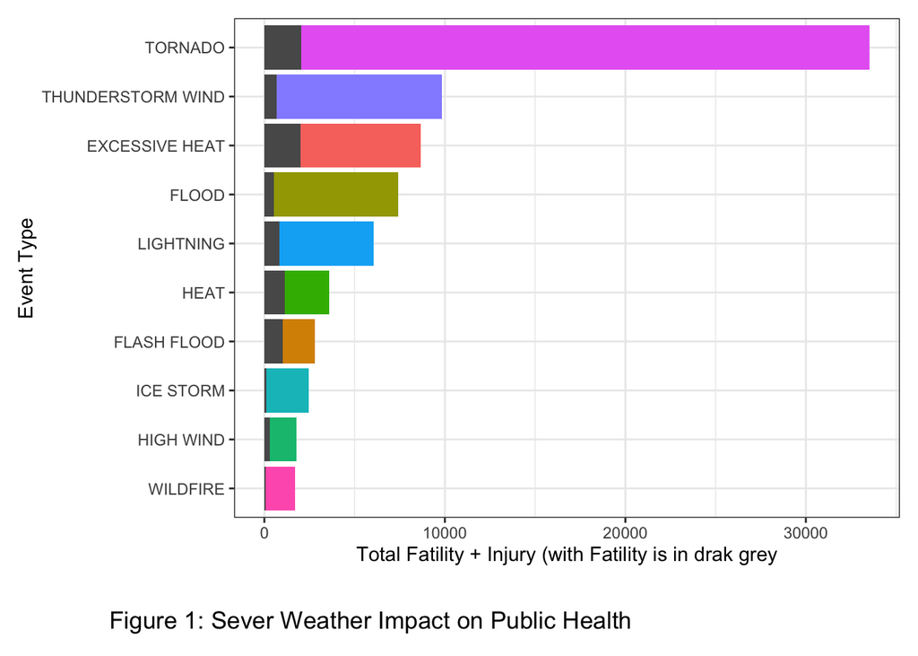

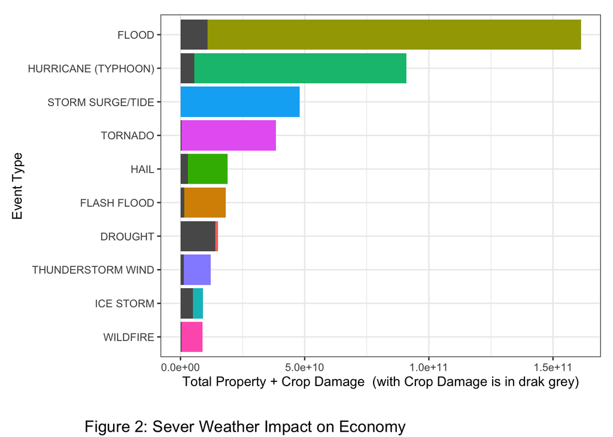